# Intro

## Who am I?

- dr. Uros Godnov
- Born 1975
- 20+ years experiences in programming, database design and BI
- Data scientist
- MCP, MCSA MS SQL 2012/2014, VBA, Python, R
- email: uros.godnov@gmail.com
- github:https://github.com/urosgodnov

[figure not shown]

## What I mostly do

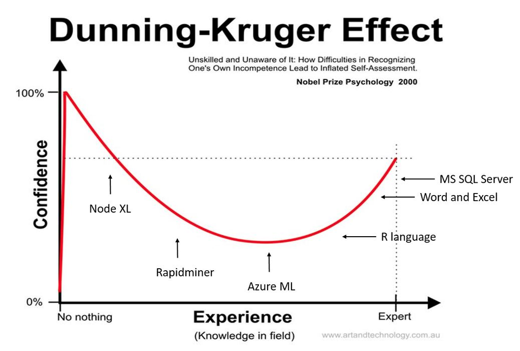

```r
include_graphics("./Pictures/DKefekt.jpg")
```

## About data science

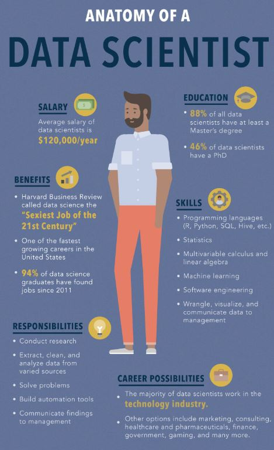

```r
include_graphics("./Pictures/Anatomy.JPG")
```

## About data science and R

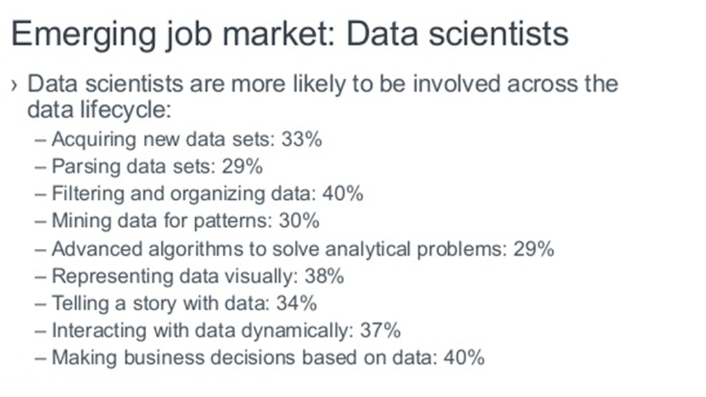

```r
include_graphics("./Pictures/DataScience.jpg")
```

## About data science and R

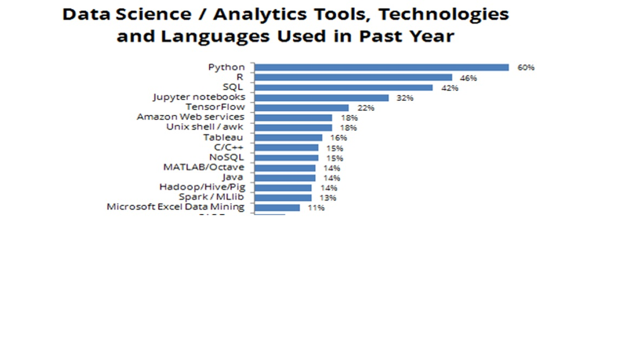

```r
include_graphics("./Pictures/DataTools.jpg")
```

## About R

- R is open source and free
- maintained by Comprehensive R Archive Network (CRAN) site at https://cran.r-project.org/

```r
contributors()
```

## About R

- 22 years from the release of R v1.0.0
- principles behind R are actually much older than 20 years and even 40 years

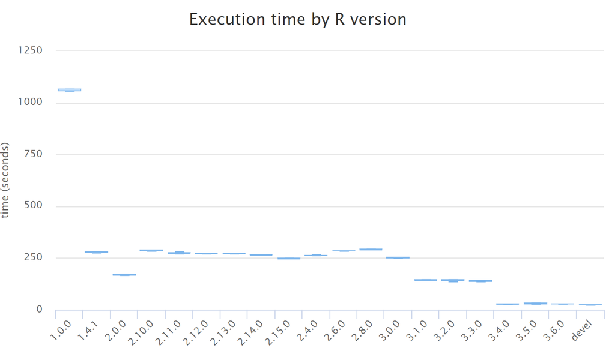

```r
include_graphics("./Pictures/speed.png")
```

## About R

- https://cran.r-project.org/
- Packages contain functions
- On 5. 4. 2017 there were 10.396 packages
- Currently (21. 01. 2024) there are 20.304 packages
- http://www.r-pkg.org/
- IDE Rstudio:
  - Intellisense
  - Markdown
  - Quarto
  - Notebooks
  - Debugging . . .
- Rstudio cheat sheets https://posit.co/resources/cheatsheets/

## About R

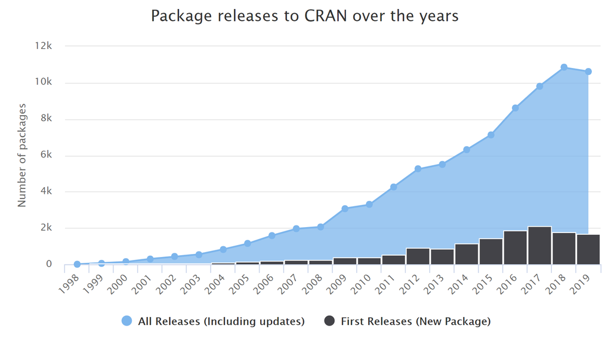

```r
include_graphics("./Pictures/packages.png")
```

## About R

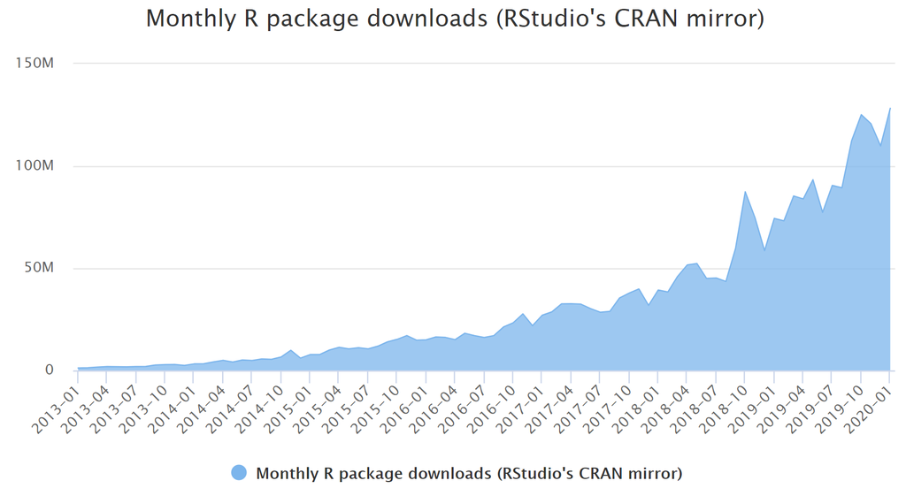

```r
include_graphics("./Pictures/downloads.png")
```

## Types of programming

- procedural
- object oriented
- functional

## Procedural

```r
factorial <- function(n) {
  result <- 1
  if (n > 1) {
    for (i in 2:n) {
      result <- result * i
    }
  }
  return(result)
}

# Calling the function
number <- 5

cat(number, "factorial is", factorial(number))
```

```
## 5 factorial is 120
```

## Object-oriented

```r
setClass(
  "Circle",
  slots = list(radius = "numeric")
)
Circle <- function(radius) {
  new("Circle", radius = radius)
}
# Define a generic function for area
setGeneric("area", function(x) standardGeneric("area"))
```

```
## [1] "area"
```

```r
# Define the method for calculating the area of a Circle
setMethod("area", "Circle", function(x) {
  pi * slot(x, "radius")^2
})
# Define a generic function for circumference
setGeneric("circumference", function(x) standardGeneric("circumference"))
```

```
## [1] "circumference"
```

```r
# Define the method for calculating the circumference of a Circle
setMethod("circumference", "Circle", function(x) {
  2 * pi * slot(x, "radius")
})
# Create a Circle object
circle <- Circle(5)

cat("The area of the circle is", area(circle), "\n")
```

```
## The area of the circle is 78.53982
```

```r
cat("The circumference of the circle is", circumference(circle))
```

```
## The circumference of the circle is 31.41593
```

## Functional programming

```r
# Functional Programming Example: Using purrr to operate on lists

# Load purrr for functional programming
library(purrr)

# A list of numbers
numbers <- list(1, 2, 3, 4, 5)

# Define a function to square a number
square <- function(x) {
  return(x^2)
}

# Use map to apply the square function to each element of the list
squared_numbers <- map(numbers, square)

# Print the result
cat("Squared numbers:", unlist(squared_numbers))
```

```
## Squared numbers: 1 4 9 16 25
```

## IDE

- RStudio
- VS Code
- Visual studio
- Atom

## RStudio

- https://www.rstudio.com/ –> https://posit.co/downloads/
- on line version of RStudio: https://rstudio.cloud/ –> https://posit.cloud/content/yours?sort=name_asc
- Google Colab

## Git - you can optinally install it

- An open-source version control system
- preferred version control system of most developers
- others delta-based version control
- Git thinks about its data more like a stream of snapshots
- [git](https://git-scm.com/downloads)

## Github - register

- the center around which all things involving Git revolve is the hub
- free/pro
- mind the bandwidth
- great for your portfolio